# Creating Graphs with ggplot2

### 1. Introduction

It is often necessary to create graphs to effectively communicate key patterns within a dataset. While many software packages allow the user to make basic plots, it can be challenging to create plots that are customized to address a specific idea. While there are numerous ways to create graphs, this tutorial will focus on the R package `ggplot2`, created by Hadley Wickham.

There are two key functions that are used in `ggplot2`:

- `qplot()`or *quick plot* is similar to base plotting functions in R and is primarily used to produce quick and easy graphics.
- `ggplot()`the *grammar of graphics plot* is different from other graphics functions because it uses a particular grammar inspired by Leland Wilkinson’s landmark book, *The Grammar of Graphics*, that focused on thinking about, reasoning with and communicating with graphics. It enables layering of independent components to create custom graphics.

```r
# This tutorial will use the following two packages
library(ggplot2)
library(mosaic)
```

**Data**: In this tutorial, we will use the [AmesHousing](http://www.amstat.org/publications/jse/v19n3/decock.pdf) data, which provides information on the sales of individual residential properties in Ames, Iowa from 2006 to 2010. The data set contains 2930 observations, and a large number of explanatory variables involved in assessing home values. A full description of this dataset can be found [here](http://www.amstat.org/publications/jse/v19n3/Decock/DataDocumentation.txt).

```r
# The csv file should be imported into rstudio:
AmesHousing <- read.csv("/Users/koechlic/Desktop/AmesHousing.csv")
head(AmesHousing)
```

```
##   Order       PID MS.SubClass MS.Zoning Lot.Frontage Lot.Area Street Alley
## 1     1 526301100          20        RL          141    31770   Pave  <NA>
## 2     2 526350040          20        RH           80    11622   Pave  <NA>
## 3     3 526351010          20        RL           81    14267   Pave  <NA>
## 4     4 526353030          20        RL           93    11160   Pave  <NA>
## 5     5 527105010          60        RL           74    13830   Pave  <NA>
## 6     6 527105030          60        RL           78     9978   Pave  <NA>
##   Lot.Shape Land.Contour Utilities Lot.Config Land.Slope Neighborhood
## 1       IR1          Lvl    AllPub     Corner        Gtl        NAmes
## 2       Reg          Lvl    AllPub     Inside        Gtl        NAmes
## 3       IR1          Lvl    AllPub     Corner        Gtl        NAmes
## 4       Reg          Lvl    AllPub     Corner        Gtl        NAmes
## 5       IR1          Lvl    AllPub     Inside        Gtl      Gilbert
## 6       IR1          Lvl    AllPub     Inside        Gtl      Gilbert
##   Condition.1 Condition.2 Bldg.Type House.Style Overall.Qual Overall.Cond
```

[output cut: 90 more lines]

### 2. The `qplot` function

In this section, we will briefly provide examples of how the `qplot` function can be used to create basic graphs. Run the code below and answer Questions 1)-5).

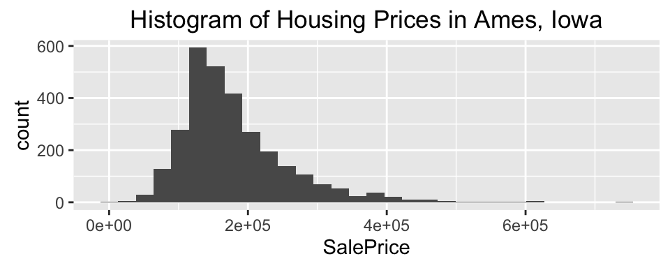

```r
# Create a histogram of housing prices
qplot(data=AmesHousing, x=SalePrice, main ="Histogram of Housing Prices in Ames, Iowa")
```

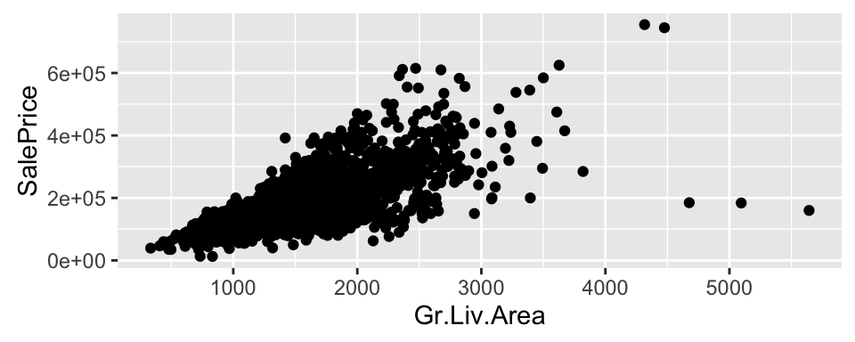

```r
# Create a scatterplot of above ground living area by sales price
qplot(data=AmesHousing,x=Gr.Liv.Area, y=SalePrice)
```

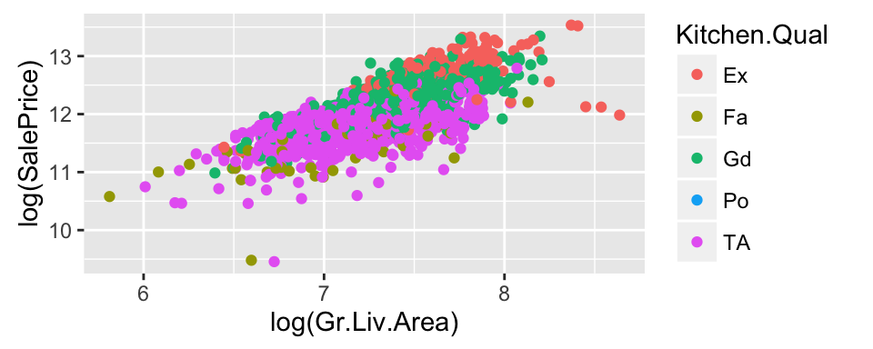

```r
# Create a scatterplot with log transformed variables, coloring by a third variable
qplot(data=AmesHousing,x=log(Gr.Liv.Area),y=log(SalePrice),color=Kitchen.Qual)
```

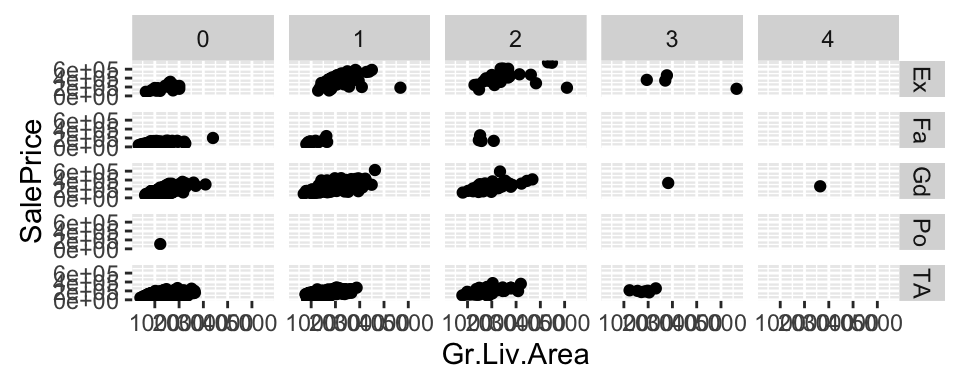

```r
# Create distinct scatterplots for each type of kitchen quality and number of fireplaces
qplot(data=AmesHousing,x=Gr.Liv.Area,y=SalePrice,facets=Kitchen.Qual~Fireplaces)
```

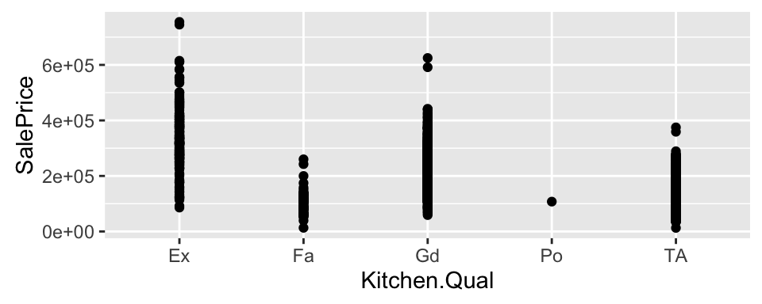

```r
# Create a dotplot of sale prices by kitchen quality
qplot(data=AmesHousing,x=Kitchen.Qual,y=SalePrice)
```

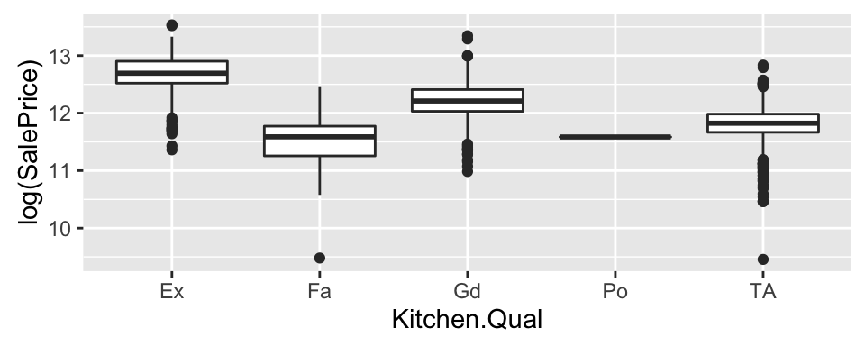

```r
# Create a boxplot of sale prices by kitchen quality
qplot(data=AmesHousing,x=Kitchen.Qual,y=log(SalePrice),geom="boxplot")
```

**Questions**:

1. In this dataset, how many houses were sold with four fireplaces?
2. What is the `facet` argument used for?
3. Based upon the data documentation, what are the five different levels for kitchen quality?
4. Do these graphs indicate that the quality of a kitchen could be related to the sale price?
5. In the RStudio console, type `?qplot`. Modify the above code to create a barchart (`geom=bar`) to count the number of sales for each level of kitchen quality. What is the deference between the color and fill command?

### 3. The basic structure of the `ggplot` function

All `ggplot` functions must have at least three components:

- **data frame**: In this activity we will be using the `AmesHousing` data.
- **geom**: to determine the type of geometric shape used to display the data, such as line, bar, point, or area.
- **aes**: to determine how variables in the data are mapped to visual properties (aesthetics) of geoms. This can include x position, y position, color, shape, fill, and size.

Thus the simplest code for a graphic made with `ggplot()` would have one of the the following forms:

- `ggplot(data, aes(x, y)) + geom_line()` or
- `ggplot(data) + geom_line(aes(x, y))`.

Note the two lines of code above would provide identical results. In the first case, the `aes` is set as the default for all `geoms`. In essense, the same `x` and `y` variables are used throughout the entire graphic. However, as graphics get more complex, it is often best to creating local `aes` mappings for each `geom` as shown in the second line of code.

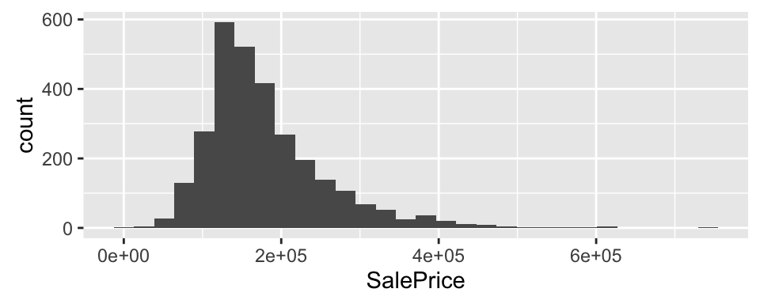

```r
# Create a histogram of housing prices
ggplot(data=AmesHousing) + geom_histogram(mapping = aes(SalePrice))
```

In the above code, the terms `data=` and `mapping=` are not required, but are used for clarification. For example, the following code will produce identical results:  
`ggplot(AmesHousing) + geom_histogram(aes(SalePrice))`.

By just looking at the above graph, would you classify the distribution of house sale prices as normal?

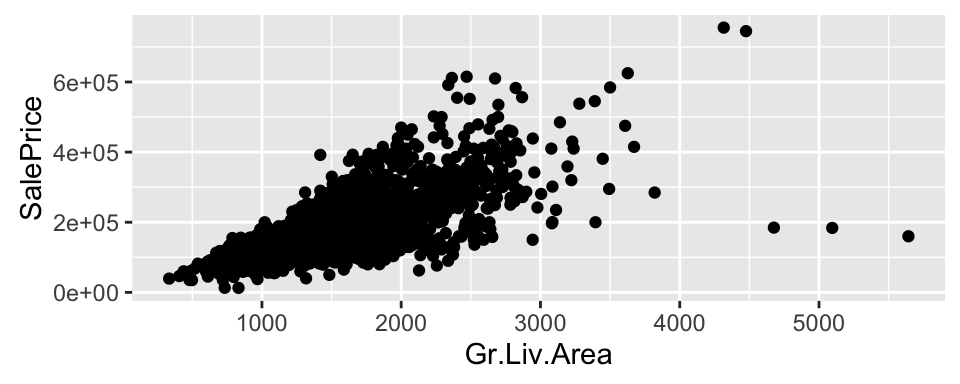

```r
# Create a scatterplot of above ground living area by sales price
ggplot(data=AmesHousing) + geom_point(mapping= aes(x=Gr.Liv.Area, y=SalePrice))
```

**Questions:**

6. Modify the code for histogram above so that the `aes` is not within the `geom`. However the resulting graph should look identical to the one above.
7. Create a scatterplot using `ggplot` with **Fireplaces** as the x-axis and **SalePrice** as the y-axis.

### 4. Customizing graphics using the `ggplot` function

In the following code, we layer additional components onto the two graphs shown above.

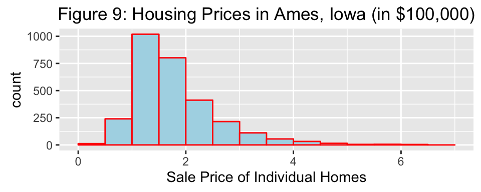

```r
ggplot(data=AmesHousing) +
      geom_histogram(mapping = aes(SalePrice/100000),
          breaks=seq(0, 7, by = 0.5), col="red", fill="lightblue") +
      labs(title="Figure 9: Housing Prices in Ames, Iowa (in $100,000)",
          x="Sale Price of Individual Homes")
```

**Remarks:**

In the code below we create three scatterplots of the log of the above ground living area by the log of sales price. Note that log() when used in R, refers to the natural logarithm (also known as ln, or the log with base e). To specify log base 10, the command log10() is used. Any other log can be specified by logb([numeric value or vector], base = [base to use]).

[figure not shown]

```r
ggplot(data=AmesHousing, aes(x=log(Gr.Liv.Area), y=log(SalePrice)) ) +
  geom_point(shape = 3, color = "darkgreen") +
  geom_smooth(method=lm,  color="green") +
  labs(title = "Figure 10", x = "log(Sale Price)", y = "Aboveground living area (sq.ft.)" )
```

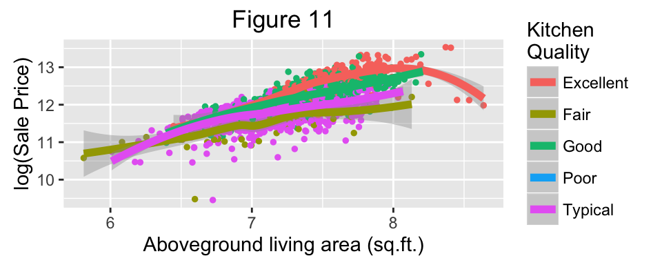

```r
ggplot(data=AmesHousing) +
  geom_point(aes(x=log(Gr.Liv.Area), y=log(SalePrice), color=Kitchen.Qual), size=1) +
  geom_smooth(aes(x=log(Gr.Liv.Area), y=log(SalePrice), color=Kitchen.Qual),
          method=loess, size=2) +
  labs(title = "Figure 11", y="log(Sale Price)", x = "Aboveground living area (sq.ft.)", color = "Kitchen\nQuality") +
  scale_color_discrete(labels = c("Excellent", "Fair", "Good", "Poor", "Typical"))
```

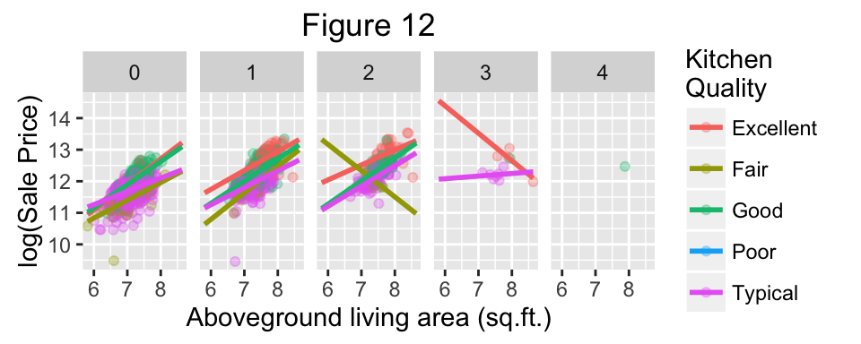

```r
ggplot(data=AmesHousing) +
  geom_point(mapping = aes(x=log(Gr.Liv.Area), y=log(SalePrice), color=Kitchen.Qual), alpha = 0.3) +
  geom_smooth(mapping = aes(x=log(Gr.Liv.Area), y=log(SalePrice), color=Kitchen.Qual),
      method=lm, se=FALSE, fullrange=TRUE) +
  facet_grid(. ~ Fireplaces) +
  labs(title = "Figure 12", y="log(Sale Price)", x = "Aboveground living area (sq.ft.)", color = "Kitchen\nQuality") +
   scale_color_discrete(labels = c("Excellent", "Fair", "Good", "Poor", "Typical"))
```

**Remarks:**

- `geom_point` is used to create a scatterplot. As shown in Figure 10, multiple shapes can be used as points. The [Data Visualization Cheat Sheet](https://www.rstudio.com/wp-content/uploads/2015/03/ggplot2-cheatsheet.pdf) lists several shape options`
- `geom_smooth` adds a fitted line through the data.
  - `method=lm` specifies a linear regression line. `method=loess` creates a smooth fit curve.
  - `se=FALSE` removes the shaded confidence regions around each line.
  - `fullrange=TRUE` extends all regression lines to the same length
- `facet_grid` and `facet_wrap` commands are used to create multiple plots. In Figure 12, we have created separate scatterplots based upon the number of fireplaces.
- When assigning fixed characteristics, the commands occur outside the `aes`, as in Figure 10, `color="green"`. When characteristics are dependent on the data, the command should occur within the `aes`, such as in Figure 11 `color=Kitchen.Qual`.
- The command `alpha`, used in Figure 12, allows adjustment of color or fill transparency. It can be extremely useful when working with a lot of data points.
- Excellent resource for working with those pesky legends : http://www.cookbook-r.com/Graphs/Legends_(ggplot2)/

In the above examples, only a few `geoms` are listed. The [ggplot2 website](http://docs.ggplot2.org/current/) lists each `geom` and gives detailed examples of how they are used. Also the ggplot2 cheatsheet provides great visualization of these geoms.

**Questions:**

8. Create a histogram of the above ground living area, `Gr.Liv.Area`.
9. Create a scatterplot using `Year.Built` as the explanatory variable and `SalePrice` as the response variable. Include a regression line, a title, and labels for the x and y axes.
10. Modify the scatterplot in Question 9) so that there is still only one regression line, but the points are colored by the overall condition of the home, `Overall.Cond`.

### 5. Additional Considerations with R graphics

**Influence of data types on graphics:** If you use the `str` command after reading data into R, you will notice that each variable is assigned one of the following `types`: Character, Numeric (real numbers), Integer, Complex, or Logical (TRUE/FALSE). In particular, the variable **Fireplaces** in considered an integer. In the code below we try to `color` and `fill` a density graph by an integer value. Notice that the color and fill commands appear to be ignored in the graph.

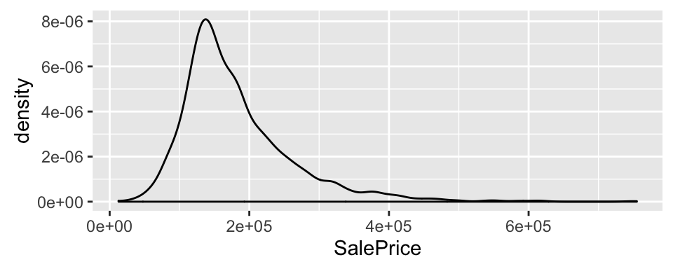

```r
# str(AmesHousing)
ggplot(data=AmesHousing) +
  geom_density(aes(SalePrice, color = Fireplaces,  fill = Fireplaces))
```

In the following code, we use the `dplyr` package to modify the AmesHousing data; we first restrict the dataset to only houses with less than three fireplaces and then create a new variable, called **Fireplace2**. The `as.factor` command creates a **factor**, wich is a variable that contains a set of numeric codes with character-valued levels. Notice that the `color` and `fill` command now work properly.

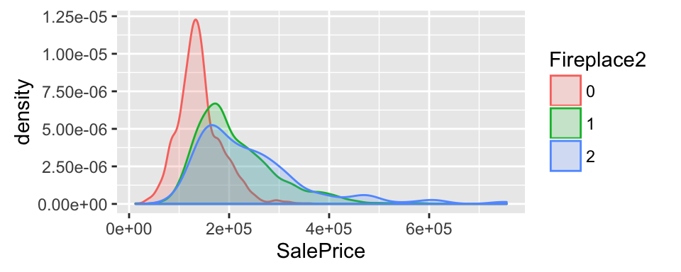

```r
# Create a new data frame with only houses with less than 3 fireplaces
AmesHousing2 <- filter(AmesHousing, Fireplaces < 3)
# Create a new variable called Fireplace2
AmesHousing2 <-mutate(AmesHousing2,Fireplace2=as.factor(Fireplaces))
#str(AmesHousing2)

ggplot(data=AmesHousing2) +
  geom_density(aes(SalePrice, color = Fireplace2,  fill = Fireplace2), alpha = 0.2)
```

**Customizing graphs:** In addition to using a **data frame**, **geoms**, and **aes**, several additional components can be added to customize each graph, such as: **stats**, **scales**, **themes**, **positions**, **coordinate systems**, **labels**, and **legends**. We will not discuss all of these components here, but the materials in the references section provide detailed explanations. In the code below we provide a few examples on how to customize graphs.

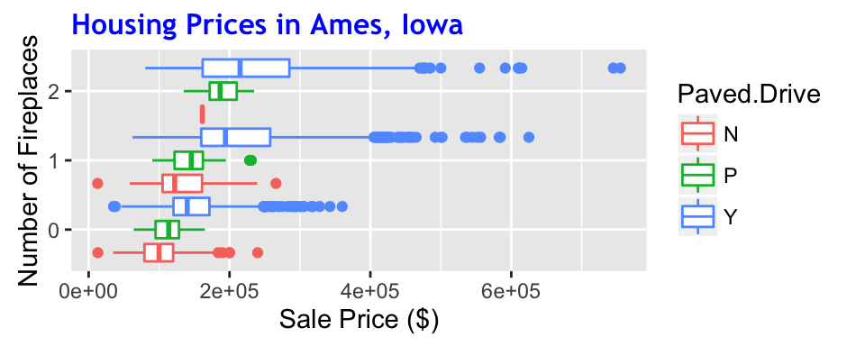

```r
ggplot(AmesHousing2, aes(x = Fireplace2, y = SalePrice, color = Paved.Drive)) +
  geom_boxplot(position = position_dodge(width = 1)) +
  coord_flip()+
  labs(title="Housing Prices in Ames, Iowa", x = "Number of Fireplaces", y = "Sale Price ($)") +
  theme(plot.title = element_text(family = "Trebuchet MS", color = "blue", face="bold", size=12, hjust=0))
```

**Remarks:**

- `position` is used to address geoms that would take the same space on a graph. In the above boxplot, `position_dodge(width = 1)` adds a space between each box. For scatterplots, `position = position_jitter()` puts spaces between overlapping points.
- `theme` is used to change the style of a graph, but does not change the data or geoms. The above code is used to modify only the title in a boxplot. A better approach for beginners is to choose among themes that were created to customize the overall graph. Common examples are `theme_bw()`, `theme_classic()`, `theme_grey()`, and `theme_minimal()`. You can also install the `ggthemes` package for many more options.

**Questions:**

13. In the density plot above, explain what the `color`, `fill`, and `alpha` commands are used for. Hint: try running the code with and without these commands or use the [Data Visualization Cheat Sheet](https://www.rstudio.com/wp-content/uploads/2015/03/ggplot2-cheatsheet.pdf).
14. In the boxplot, what is done by the code `coord_flip()`?
15. Create a new boxplot, similar to the one above, but use `theme_bw()` instead of the given theme command. Explain how the graph changes.
16. Use the tab completion feature in RStudio (type theme and hit the `Tab` key to see various options) to determine what theme is the default for most graphs in ggplot.

### 7. On your own

In order to complete this activity, you will need to go through the `dplyr` tutorial and use the `dplyr` package to manipulate the dataset before making any graphics.

- Restrict the `AmesHousing` data to only sales under normal conditions. In other words, `Condition.1 == Norm`
- Create a new variable called `TotalSqFt = GR.Liv.Area + Total.Bsmt.SF` and remove any homes with more than 3000 total square feet.
- Create a new variable, where `No` indicates no fireplaces in the home and `Yes` indicates at least one fireplace in the home.
- With this modified data file, create a graphic involving no more than three explanatory variables that best portrays how to predict sales price. For example, Figure 12 uses a linear model of kitchen quality, above ground square footage, and number of fireplaces to predict sale price.

### Additional resources

- https://www.youtube.com/watch?v=HeqHMM4ziXA and https://www.youtube.com/watch?v=n8kYa9vu1l8: Two introductory videos on ggplot2 by Roger Peng.
- https://www.rstudio.com/wp-content/uploads/2015/03/ggplot2-cheatsheet.pdf: Data Visualization with ggplot2 Cheat Sheet
- http://docs.ggplot2.org/current/: A well-documented list of ggplot2 components with descriptions
- http://www.statmethods.net/advgraphs/ggplot2.html: Quick-R introduction to graphics
- http://cran.r-project.org/web/packages/ggplot2/ggplot2.pdf: Formal documentation of the ggplot2 package
- http://www.ceb-institute.org/bbs/wp-content/uploads/2011/09/handout_ggplot2.pdf: A tutorial on ggplot2 by Hadley Wickham.
- http://stackoverflow.com/tags/ggplot2: Stackoverflow, an online community to share information.
- http://www.cookbook-r.com/Graphs/: R Graphics Cookbook, a text by Winston Chang http://ggplot2.org/book/ : Sample chapters of Hadley Wickhams text, ggplot2: Elegant Graphics for Data Analysis